# TDDE01 exam solution

## Assignment 1, part 1

```r
data=read.csv("Bikes.csv")

n=dim(data)[1]
set.seed(12345)
id=sample(1:n, floor(n*0.6))
train=data[id,]
test=data[-id,]

library(caret)

scaler=preProcess(train)
trainS=predict(scaler,train)
testS=predict(scaler, test)

covariates=trainS[,-1]
response=trainS[,1]

library(glmnet)

set.seed(12345)
model=cv.glmnet(as.matrix(covariates),
                response, alpha=1,family="gaussian")
model$lambda.min
```

```
## [1] 0.0006253445
```

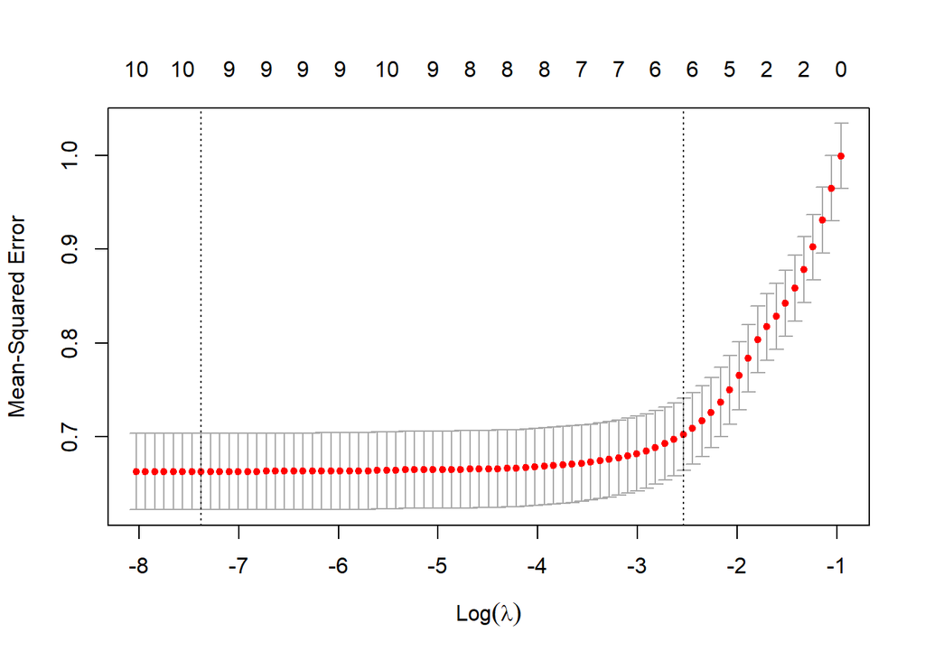

```r
plot(model)
```

Optimal penalty parameter is therefore 0.000625. Interpretation in terms of bias-variance tradeoff: when log-penalty parameter is increasing, the model complexity is decreasing, and this leads to increased bias and decreased variance.

```r
coef(model, s="lambda.1se")
```

```
## 11 x 1 sparse Matrix of class "dgCMatrix"
##                                  s1
## (Intercept)           -8.742707e-17
## Hour                   2.264222e-01
## Temperature            2.852890e-01
## Humidity              -9.808210e-02
## Wind.speed             .
## Visibility             .
## Dew.point.temperature  .
## Solar.Radiation        .
## Rainfall              -1.702395e-02
## Snowfall              -6.135284e-02
## Holiday                1.086443e-01
```

Equation is therefore: $Rental_Bikes=0.226*Hour+0.285*Temperature-0.098*Humidity-0.017*Rainfall-0.061*Snowfall+0.11*Holiday$

## Assignment 1, part 2

```r
Ypred=predict(model, as.matrix(covariates), s="lambda.1se" )[,1]
MSE=mean((Ypred-response)^2)

testX=testS[1,-1]
Ytest=predict(model, as.matrix(testX), s="lambda.1se" )
CI=c(Ytest-1.96*sqrt(MSE), Ytest+1.96*sqrt(MSE))

print(CI)
```

```
## [1] -2.031268  1.240571
```

Model assumptions that make these computations possible is that the target is normally distributed with mean given by ‘Ypred’ in the code, and the variance which we estimated as train MSE.

## Assignment 1, part 3

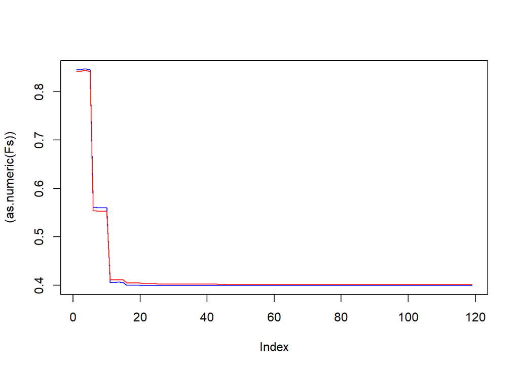

```r
costF<-function(Y, Yfit){
  R=abs(Y-Yfit)
  return(mean(R))
}

x=as.matrix(trainS[,c(4,6)])
xt=as.matrix(testS[,c(4,6)])

Fs=list()
k=0
TestE=list()
Theta=list()

myCost= function(theta){
  f=costF(trainS$Dew.point.temperature, x%*%theta)
  .GlobalEnv$k= .GlobalEnv$k+1
  .GlobalEnv$Fs[[k]]=f
  .GlobalEnv$TestE[[k]]=costF(testS$Dew.point.temperature, xt%*%theta)
  .GlobalEnv$Theta[[k]]=theta
  return(f)
}

res=optim(rep(0,2), fn=myCost,  method="BFGS")


plot((as.numeric(Fs)), type="l", col="blue")
points((as.numeric(TestE)), type="l", col="red")
```

```r
which.min(TestE)
```

```
## [1] 49
```

From here we can see that the test error does not improve after 49 iterations so it can be stopped there.

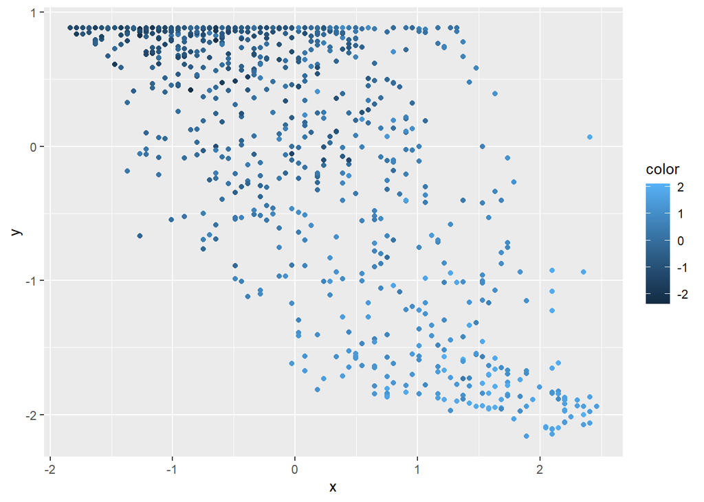

```r
Pred1=xt%*%Theta[[which.min(TestE)]]
Pred2=xt%*%Theta[[5]]


df=data.frame(x=xt[,1], y=xt[,2], color=testS$Dew.point.temperature)
ggplot(df,aes(x=x,y=y,color=color))+geom_point()
```

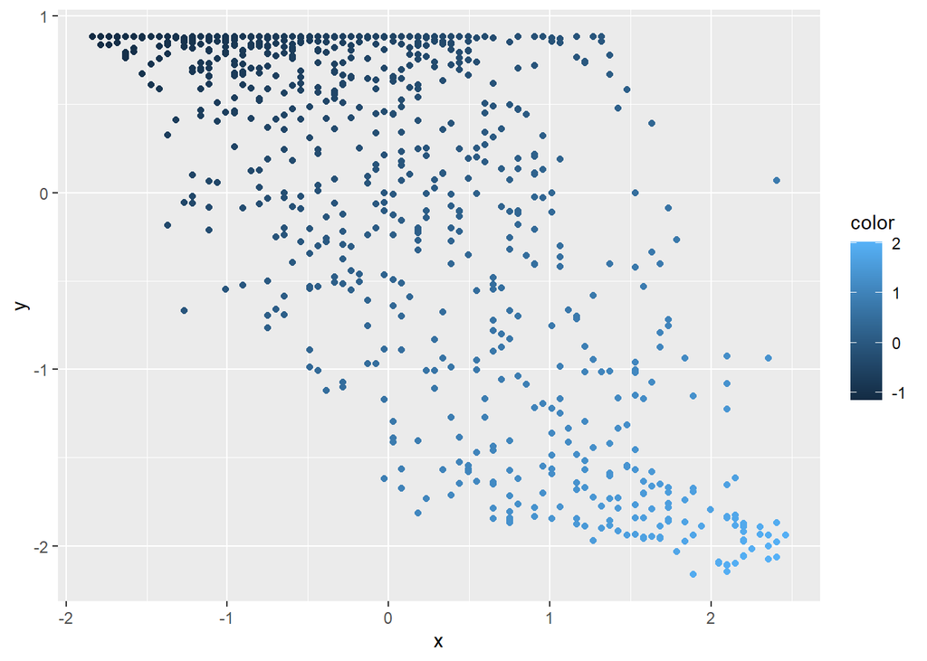

```r
df=data.frame(x=xt[,1], y=xt[,2], color=Pred1)
ggplot(df,aes(x=x,y=y,color=color))+geom_point()
```

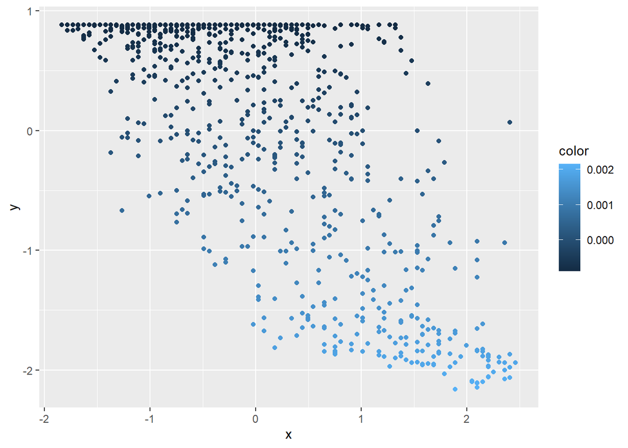

```r
df=data.frame(x=xt[,1], y=xt[,2], color=Pred2)
ggplot(df,aes(x=x,y=y,color=color))+geom_point()
```

**Note** If the student makes these plots with training data or full data, no point reduction should be done since assignment does not specify which data to use in plots